# Ejercicios Módulo 01

xto sarcior

2023-10-06

## ESTADÍSTICA DESCRIPTIVA

1. Los siguientes datos corresponden al número de veces que el programa Minihard Word se “colgó” durante un mes en cada uno de los 50 ordenadores de nuestra empresa. Comprobad que se satisface la regla de Tchebichev para m = 1, m = 2 y m = 3.

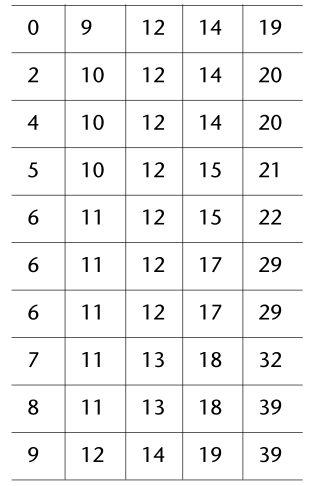

   Tabla de observaciones

   - Primero calculamos la media y la desviación típica:

     ```r
     datos <- c(0,2,4,5,6,6,6,7,8,9,9,10,10,10,11,11,11,11,11,12,12,12,12,12,12,12,12,
     13,13,14,14,14,14,15,15,17,17,18,18,19,19,20,20,21,22,29,29,32,39,39)
     media <- mean(datos)
     desviacion <- sd(datos)
     ```

     La media es 14.28 y la desviación típica es 8.1842058.
   - Ahora calculamos los intervalos para m = 1, m = 2 y m = 3 utilizando la regla de Tchebichev $(\bar{x} - m \cdot s_x, \bar{x} + m \cdot s_x)$:
     - Para $m = 1 \Rightarrow (14.28 - 1 \cdot 8.18, 14.28 + 1 \cdot 8.18) = (6.1, 22.46)$
     - Para $m = 2 \Rightarrow (14.28 - 2 \cdot 8.18, 14.28 + 2 \cdot 8.18) = (-2.08, 30.64)$
     - Para $m = 3 \Rightarrow (14.28 - 3 \cdot 8.18, 14.28 + 3 \cdot 8.18) = (-10.26, 38.82)$
   - Anotamos las observaciones en cada intervalo:
     - $(6.1, 22.46) \Rightarrow 38$
     - $(-2.08, 30.64) \Rightarrow 47$
     - $(-10.26, 38.82) \Rightarrow 48$
   - Calculamos los porcentajes para cada intervalo:
     - $\displaystyle (6.1, 22.46) \Rightarrow \frac{38}{50} = 0.76 \Rightarrow 76\%$
     - $\displaystyle (-2.08, 30.64) \Rightarrow \frac{47}{50} = 0.94 \Rightarrow 94\%$
     - $\displaystyle (-10.26, 38.82) \Rightarrow \frac{48}{50} = 0.96 \Rightarrow 96\%$
   - Calculamos el porcentaje mínimo previsto por la regla de Tchebichev $\displaystyle \left( 1 - \frac{1}{m^2} \right)$:
     - $\displaystyle (6.1, 22.46) \Rightarrow 1 - \frac{1}{1^2} = 0$
     - $\displaystyle (-2.08, 30.64) \Rightarrow 1 - \frac{1}{2^2} = 0.75 \Rightarrow 75\%$
     - $\displaystyle (-10.26, 38.82) \Rightarrow 1 - \frac{1}{3^2} = 0.88 \Rightarrow 88\%$

   La regla de Tchebichev indica el porcentaje mínimo que podemos encontrar en el intervalo. Observamos que en todos los casos hay más observaciones en los intervalos que los previstos por la regla.
   - Finalmente, dibujamos una tabla donde podemos ver resumidos todos los datos:

   | m | Intervalo | Observaciones en el intervalo | Porcentaje de observaciones en el intervalo | Porcentaje mínimo previsto por la regla de Tchebichev |
   | --- | --- | --- | --- | --- |
   | 1 | $(\bar{x} - 1s_x, \bar{x} + 1s_x) = (6.1,22.46)$ | $38$ | $38/50 = 76 \%$ | $0 \%$ |
   | 2 | $(\bar{x} - 2s_x, \bar{x} + 2s_x) = (-2.08, 30.64)$ | $47$ | $47/50 = 94 \%$ | $75 \%$ |
   | 3 | $(\bar{x} - 3x_x, \bar{x} + 3s_x) = (-10.26, 38.82)$ | $48$ | $48/50 = 96 \%$ | $88 \%$ |